# Data Science, Séance 4 : Données sur le web + scrapping et API

Etienne Côme

21 novembre 2019

## Où trouver des données sur le web

- instituts publics : [insee](http://www.insee.fr), [ign](http://professionnels.ign.fr/catalogue), …
- portails open-data : data.iledefrance.fr, data.gouv.fr, …
- sites collaboratifs : [wikipedia (dbpedia)](http://fr.dbpedia.org/), [openstreetmap](http://download.geofabrik.de/), …
- sites specialisés : [météo](http://french.wunderground.com/history/airport/LFPO/2014/9/10/DailyHistory.html?), [sports](http://www.footballstats.fr/), [logement](http://www.meilleursagents.com/api/geo2/get_idf_pricemap_info?x=2.32&y=48.67&z=10), [annonces](http://www.leboncoin.fr), …
- réseaux sociaux : [twitter](https://dev.twitter.com/rest/public), [flickR](https://www.flickr.com/services/api/), [foursquare](http://gnip.com/sources/foursquare/), …
- moteur de recherche : [google](https://developers.google.com/apis-explorer/#p/), [yahoo](https://developer.yahoo.com/everything.html), [bing](http://www.bing.com/dev/en-us/dev-center), …
- api spécialisées : [velib](http://developpers.jcdecaux.fr), …

## Où trouver des données sur le web

#### Jeux de données, déjà mis en forme

- instituts publics : [insee](http://www.insee.fr), [ign](http://professionnels.ign.fr/catalogue), …
- portails open-data : data.iledefrance.fr, data.gouv.fr, …
- sites collaboratifs : [wikipedia (dbpedia)](http://fr.dbpedia.org/), [openstreetmap](http://download.geofabrik.de/)

## Où trouver des données sur le web

#### Jeux de données à mettre en forme

#### Scrapping

- sites specialisés : [météo](http://french.wunderground.com/history/airport/LFPO/2014/9/10/DailyHistory.html?), sports, [logement](http://www.meilleursagents.com/api/geo2/get_idf_pricemap_info?x=2.32&y=48.67&z=10), [annonces](http://www.leboncoin.fr), …

#### API

- sites collaboratifs : [openstreetmap](http://overpass-api.de/), …
- réseaux sociaux : [twitter](https://dev.twitter.com/rest/public), [flickR](https://www.flickr.com/services/api/), [foursquare](http://gnip.com/sources/foursquare/), …
- moteur de recherche : [google](https://developers.google.com/apis-explorer/#p/), [yahoo](https://developer.yahoo.com/everything.html), [bing](http://www.bing.com/dev/en-us/dev-center), …
- api spécialisées : [velib](http://developpers.jcdecaux.fr), …

## Scrapping

#### Extraire des informations spécifiques

#### d’une ou plusieurs pages web

#### en vu de constituer un jeu de données

## Scrapping, le html

```html
<!DOCTYPE html>
<head><meta charset="utf-8"></head>
<body>
<section style="padding-top:6em;text-align:center">
<h1 class="purple"> Scrapping </h1>
<h4 class="purple">Extraire des informations spécifiques</h4>
<h4 class="purple">d'une ou plusieurs pages web</h4>
<h4 class="purple">en vu de constituer un jeu de données</h4>
</section>
</body>
</html>
```

## Scrapping, les package RCurl et XML

#### RCurl (Client URL Request Library)

le web en ligne de commande : [get, post](http://www.w3.org/Protocols/rfc2616/rfc2616-sec9.html), [https](http://fr.wikipedia.org/wiki/HyperText_Transfer_Protocol_Secure), [ftp](http://fr.wikipedia.org/wiki/File_Transfer_Protocol), …

```r
library(RCurl)
# récupérer la page
res  = getURL("http://www...")
```

#### XML

htmlTreeParse, getNodeSet :

```r
# parse du html
resp  = htmlTreeParse(res,useInternal=T)
# fonction de haut niveau pour récupérer les tableaux
rest  = readHTMLTable(resp)
# récupérer un noeud désiré (xpath)
node  = getNodeSet(resp, '//nav/ul/')
```

## Scrapping, les package RCurl et XML

#### Xpath, extraire des informations d’un arbre DOM

Syntaxe pour se promener dans l’abre dom et en extraire des partie (noeuds, attributs, …), plus détails sur [w3schools](http://www.w3schools.com/xpath/xpath_syntax.asp).

| Expression | Description |
| --- | --- |
| *nodename* | Selects all nodes with the name “*nodename*” |
| / | Selects from the root node |
| // | Selects nodes in the document from the current node that match the selection |
| . | Selects the current node |
| .. | Selects the parent of the current node |
| @ | Selects attributes |

## Scrapping, les package RCurl et XML

#### Xpath, extraire des informations d’un arbre DOM

Syntaxe pour se promener dans l’abre dom et en extraire des partie (noeuds, attributs, …), plus détails sur [w3schools](http://www.w3schools.com/xpath/xpath_syntax.asp).

| Expression | Description |
| --- | --- |
| /bookstore/book[1] | Selects the first book element that is the child of the bookstore element. |
| //title[@lang] | Selects all the title elements that have an attribute named |
| //title[@lang='en'] | Selects all the title elements that have an attribute named lang with a value of ‘en’ |
| /bookstore/book[price>35.00] | Selects all the book elements of the bookstore element that have a price > 35.00 |

## Library

```r
library(XML)
library(RCurl)
library(dplyr)
library(rjson)
library(httr)
```

## Scrapper stackoverflow.com

Ecrire un script R permettant de scrapper le nombre de question publier sur les sites ayant les tags : **‘python’,‘julia-lang’,‘r’,‘sas’,‘matlab’,‘ggplot2’ et ‘d3.js’**. Réaliser un graphique à partir de ces données.

[figure not shown]

```r
# definition des termes à scrapper
languages=c('python','r','sas','matlab','ggplot2')
# initialisation de la table
stackOF=data.frame(lang=languages,questions=NA)
# boucle sur les termes
for(i in 1:length(languages)){
  # récupérer la page
  base = "https://stackoverflow.com/questions/tagged/"
  res  = getURL(paste(base,stackOF[i,'lang'],sep=''))
  # la parser et récupérer le noeud désiré (xpath)
  resp = htmlTreeParse(res,useInternal=T)
  ns1  = getNodeSet(resp, "//*[@id='mainbar']/div[4]/div/div[1]")
  # récupérer la valeure et la nettoyer
  val  = xmlValue(ns1[[1]])
  valclean =  gsub("questions","",val);
  valclean = gsub("[ ,\n,\r]","",valclean)
  stackOF[i,'questions'] = as.numeric(valclean)
}
# faire un graphique
stackOF=stackOF[order(stackOF$questions,decreasing=T),]
```

```r
date = format(Sys.time(), "%d/%m/%Y")
title=paste("Popularité sur stackOverFlow",date)
barplot(stackOF$questions,
        names.arg=stackOF$lang,
        main=title,ylab="Nombre de questions")
```

## Scrapper stackOverFlow

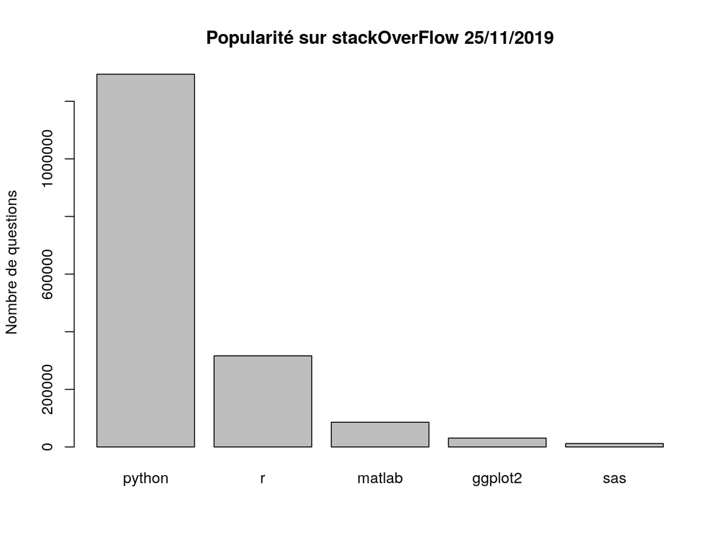

## Scrapper leboncoin.fr

Ecrire un script R permettant de scrapper le nombre d’annonce de particulier du site dans la catégorie “Jardinage” en région centre.

[figure not shown]

## Scrapper les résultats de ligue 1

#### Récupérer les dix dernières années de résultats du championnat de france

## Scrapper les résultats de ligue 1

```r
# récupérer la page et la parser
year = 2018
url_b ="http://www.footballstats.fr/resultat-ligue1-"
res  = getURL(paste(url_b,year,".html",sep=''))
resp = htmlTreeParse(res,useInternal=T)
# récupérer le bon tableau de la page
rest = readHTMLTable(resp)[[2]]
```

## Scrapper les résultats de ligue 1

```r
# le remettre légèrement en forme
rest = rest[!is.na(rest[,2]),1:4]
names(rest) = c('locaux', 'visiteur','resultat','affluence')
rest$locaux=factor(as.character(rest$locaux),
                   levels=unique(rest$locaux))
rest$affluence=as.numeric(as.character(rest$affluence))
rest$visiteurs=factor(as.character(rest$visiteur),
                      levels=unique(rest$locaux))
resm=matrix(unlist(strsplit(as.character(rest$resultat),'-')),2)
rest$resultat.locaux=as.numeric(resm[1,])
rest$resultat.visiteurs=as.numeric(resm[2,])
```

## Scrapper les résultats de ligue 1

```r
# remise en forme et calcul des totaux de buts marqués / encaissés
resdom = rest  %>% group_by(locaux) %>%
  summarise(Abutdom=sum(resultat.locaux),
            Dbutdom=sum(resultat.visiteurs),
            affdom=mean(affluence,na.rm=TRUE))

resext = rest  %>% group_by(visiteur) %>%
  summarise(Abutext=sum(resultat.visiteurs),
            Dbutext=sum(resultat.locaux),
            affext=mean(affluence,na.rm=TRUE))

res = resdom %>% left_join(resext,by=c("locaux"="visiteur")) %>%
  mutate(D=Dbutdom+Dbutext,A=Abutdom+Abutext)
```

## Scrapper les résultats de ligue 1

```r
# faire un graphique
ti = paste("Ligue 1, Saison",year)
xl = "Buts marqués"
yl = "Buts encaissés"
plot(res$A,res$D,xlab=xl,ylab=yl,col="white",main=ti)
text(res$A,res$D,res$locaux,cex=res$affdom/20000)
```

## Scrapper les résultats de ligue 1

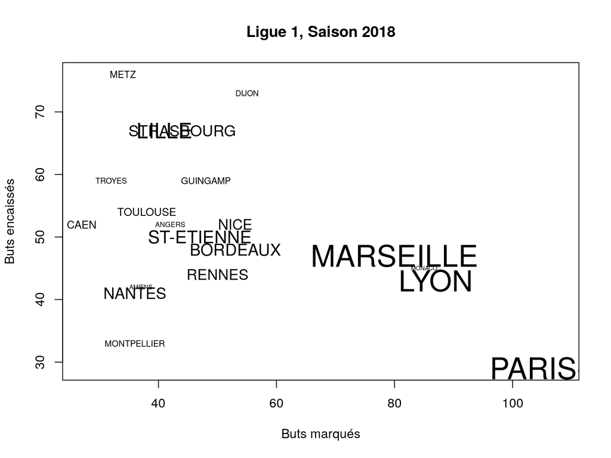

# API Application Programming Interface

## Vélib’ et altitude des stations

Localisation des stations

```r
# récupérer la liste des stations et la mettre en forme
url="http://vlsstats.ifsttar.fr/data/input_Lyon.json"
stationsList=fromJSON(file=url)
data=sapply(stationsList,function(x){
    c(x$number,x$name,x$address,
      x$bike_stands,x$position$lat,x$position$lng)
    })
stations=data.frame(id=as.numeric(data[1,]),name=data[2,],
        adresse=data[3,],   nbdocks=as.numeric(data[4,]),
        lat=as.numeric(data[5,]),long=as.numeric(data[6,]),alt=NA)
```

## Vélib’ et altitude des stations

API elevation

```r
chunk_size = 10
# récupérer les altitudes
base  = "https://elevation-api.io/api/elevation?points="
for (i in 1:ceiling(nrow(stations)/chunk_size)){
system("sleep 0.5")
print(i)
iv   = ((i-1)*chunk_size+1):min((i*chunk_size),dim(stations)[1])
latlong = paste0("(",stations[iv,'lat'],",",stations[iv,'long'],")")
query = paste(latlong,collapse=',')
url   = paste(base,query,sep="")
res   = fromJSON(file=url)
stations$alt[iv]=sapply(res$elevations,function(x){x$elevation})
}
```

## Vélib’ et altitude des stations

```r
# calculer l'indice de charge moyenne
url = "http://vlsstats.ifsttar.fr/data/spatiotemporalstats_Lyon.json"
stationsData = fromJSON(file=url)
res = sapply(stationsData,function(x){
  c(x$'_id', mean(x$available_bikes))})
res = data.frame(t(res),row.names = NULL)
names(res) = c('id','mnbikes')
stations =  stations%>% left_join(res)
```

```
FALSE Joining, by = "id"
```

```r
stations$loading = stations$mnbikes/stations$nbdocks
ti = "Effet de l'altitude sur la charge des stations"
yl = "Indicateur de charge moyenne"
xl = "Altitude (m)"
plot(stations$alt,stations$loading,xlab=xl,ylab=yl,main=ti)
```

## Vélib’ et altitude des stations

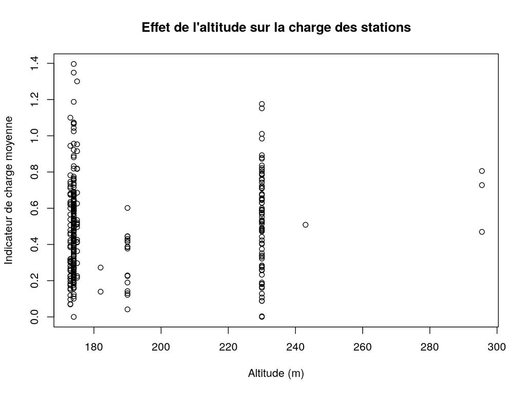

## API suite

Ecrire une fonction permettant de récupérer le nombre de fan d’un artiste en utilisant l’api deezer.

vous vous servirez de la fonction search et de la fonction [artist](https://developers.deezer.com/api/search) de cette API.